# Homework 7

For each problem below create a new markdown cell and generate the requested content. A careful review of the .ipynb file for Lecture 7 will provide what you need, though you will have to combine ideas and do some experimenting to figure things out. Remember, you can `double-click` on Markdown cells to see and edit the underlying Markdown, then use `ctrl-enter` to run them. When you create a new cell, change it from Code to Markdown by using `esc-m` or the menu above.

## Problem 1 (1 point)

Recreate this table of Antoine equation parameters from Homework 3 using Markdown. Note whether columns are left-, center-, or right-aligned.

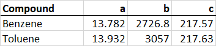

| Compount | a | b | c |
| --- | --- | --- | --- |
| Benzene | 13.782 | 2726.8 | 217.57 |
| Toluene | 13.932 | 3057 | 217.63 |

## Problem 2 (3 points)

The following was part of Homework 5. Recreate the problem statement within a Markdown cell. The text and equations must match in every particular, although lines of text may wrap at different points. Equations must be generated by Latex math commands. Note that some equations are "in-line" and some equations occupy their own lines. Also note that there is always a space between a number and its associated units and that units are not italicized.

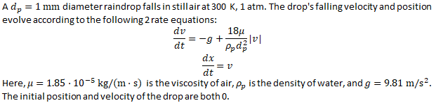

A $d_p = 1 \, \text{mm}$ diameter raindrop falls in still air at $300 \, \text{K}, 1 \, \text{atm}$. The drop's falling velocity and position evolve according to the following 2 rate equations: $$ \frac{dv}{dt} = -g + \frac{18\mu}{\rho_pd_p^2}|v|$$ $$ \frac{dx}{dt} = v$$ Here, $\mu = 1.85 \cdot 10^{-5} \, \text{kg}/(\text{m} \cdot \text{s})$ is the viscocity of air, $\rho_p$ is the density of water, and $g = 9.81 \, \text{m}/\text{s}^2$.

## The initial position and velocity of the drop are both 0.

## Problem 3 (3 points)

The following equations were used in Homework 4. Recreate them using Latex math commands within Markdown. The sizes of symbols, the Greek letters, spacing, and other formatting should match between my version and yours.

$\begin{aligned} y(t) = 5 \left[ 1-\text{exp} \left (-\frac{t-\theta}{\tau} \right ) \right] S(t) \end{aligned}$

$\begin{aligned} S(t) = \left\{ \begin{array}{ll} 0 \quad \text{when} \, t \lt \theta \\ 1 \quad \text{when} \, t \ge \theta \end{array} \right. \end{aligned}$

## Problem 4 (1 point)

Create a markdown cell with an embedded/attached image obtained from some website. Also include a clickable link below the image to the webpage where you obtained it. The "best three" images (as judged by the TAs) will get an in-class award.